# Correlation of discrete traits

Rosana Zenil-Ferguson

2025-10-21

## Call your libraries for work

```r
library(ape)
library(phytools)
```

## Reading data for phylogenetic comparative methods

First download the data for this tutorial and put it in the same folder where you have your projects for this class. The data comes from Cássia‐Silva, C., Oliveira, R.S., Sales, L.P., Freitas, C.G., Jardim, L., Emilio, T., Bacon, C.D. and Collevatti, R.G., 2022. Acaulescence promotes speciation and shapes the distribution patterns of palms in Neotropical seasonally dry habitats. Ecography, 2022(3), p.e06072.

Make sure you take time looking at the data and the phylogenetic tree

1. [Phylogeny](https://github.com/roszenil/BIO508-Evolution/blob/main/practicals/downloads/Cocoseae_tree_MCC.txt)
2. [Dataset](https://github.com/roszenil/BIO508-Evolution/blob/main/practicals/downloads/cocoseae_data2.csv)

## Check your tree

A good practice is always to open your kind of tree format you have and then call the appropriate function. For example use `read.newick()` or `read.nexus()`

```r
# 1. read the tree from here. This is a newick file (1 pt)
palm.tree =

# 2. Is this tree ultrametric? is it binary? Write the code- 1pt


# 3. Plot your tree in circular shape (1 pt). Use "fan" as the shape and the labels size 0.3 (1pt)
```

This is how your tree should look like

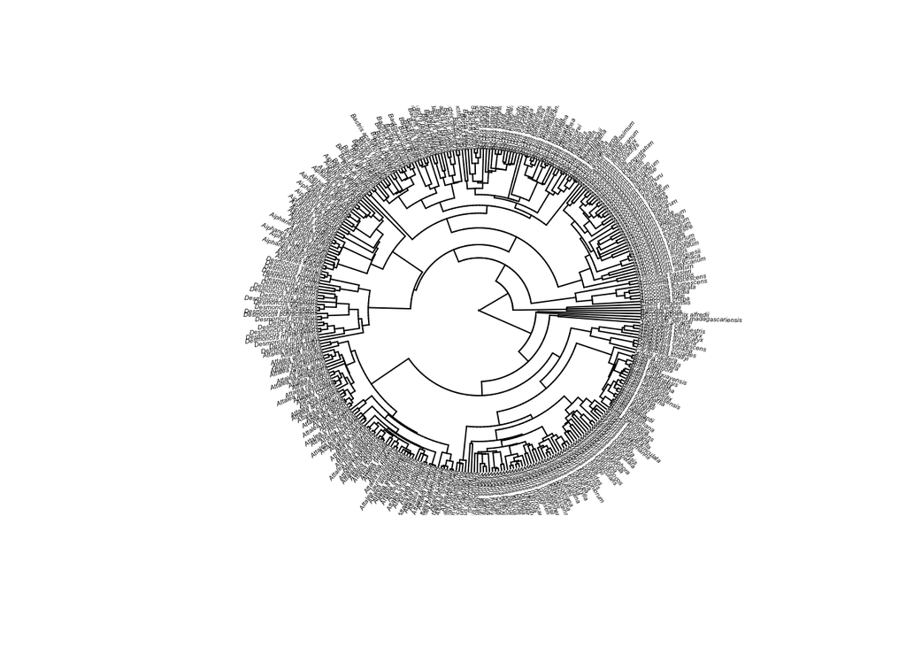

Let’s calculate how old is the phylogenetic tree.

```r
max(nodeHeights(palm.tree))

# 3. What does this number represent?
```

## Visualize the data

First lets read the data

```r
#4. Read your csv data, with the first column as the row.names -1 pt
palm.data= a_function_goes_here(file="cocoseae_data2.csv", row.names = ?, stringsAsFactors = TRUE)

head(palmdata)
```

Look at the data!

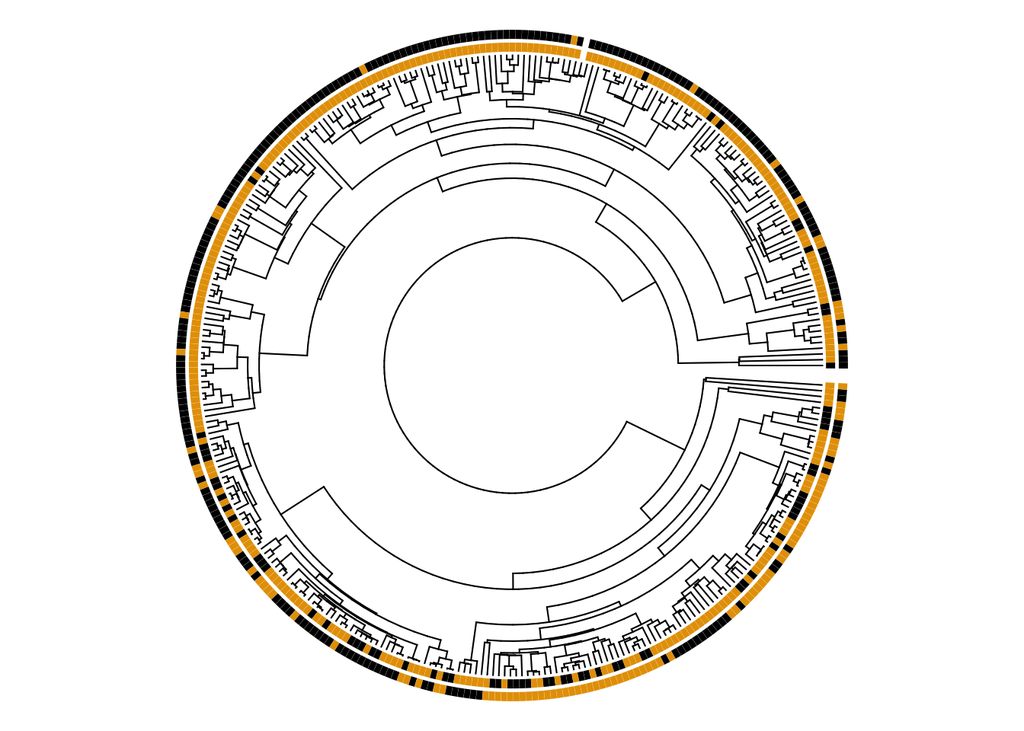

```r
# install.packages("plotrix") Install this package if you don't have it?
library(plotrix)
plotFanTree.wTraits(palm.tree,palm.data,ftype="off")
```

## Pagel correlation test

5. In your own words describe what is a Pagel’s correlation test (2pts)

Now let’s perform the test, for this you will need to read the data differently

```r
tree <- read.tree("Cocoseae_tree_MCC.txt")
data <- read.csv("cocoseae_data2.csv")

names(data)
# 6. What is the difference between reading the data above and this reading of data? There is a small difference but it makes or breaks your analysis (1 pt)
head(data)

## Reading each of the traits, check what are their levels
trait1 <- setNames(data$growth_form, data$species)
trait2 <- setNames(data$habitat, data$species)



## Now let's perform the test
fit <- fitPagel(tree, trait1, trait2, method = "fitDiscrete", pi = "fitzjohn")
```

Now let’s look at the object fit, this object has a lot of information in it

7. What is the rate to evolve from acaulescent to non-acaulescent in the rainforest for the independent model? Please write the number with the units we discussed in the last class (1pt)
8. Which rate in the independent model is equal to the rate in #7 and why?
9. Looking at your answers in #7 and #8 what is the independent model assumming? (1 pt)
10. Look at those same rates from acaulescent to non-acaulescent in the rainforest or in seasonally dry forest for the dependent model. What is happening? (2 pts)
11. Knowing now the answers to #9 and #10 what do you expect in terms of evolution of growth form and habitat, correlated or not? (1 pt)
12. Look formally at the likelihood ratio test. Which is the value of the LRT test statistic? (1pt)

```r
# 13. Calculate the p-value, fill in the question marks to do it. The goal with this is for you to make sure where the test comes from (2 pts)

LRT= ?
pval <- pchisq(?, df = ?, lower.tail = FALSE)
```